# Analysis of Population Density and Happiness Pattern

Then, I looked at the relationship between population density and happiness across countries. By categorizing countries into population density tiers and analyzing happiness scores (Life Ladder), it demonstrated patterns and clustering in global well-being.

```r
# Load libraries
library(tidyverse)
library(sf)
library(spdep)
library(viridis)
library(readxl)
library(rnaturalearth)
library(rnaturalearthdata)
library(corrplot)
```

```r
# Load spatial and happiness datasets
world_sf <- rnaturalearth::ne_countries(scale = "medium", returnclass = "sf")
happiness_data <- read_excel("../data/WHR20_DataForTable2.1.xls")
```

```r
# Select relevant columns
happiness_data <- happiness_data %>%
  select(
    `year`, `Country name`, `Life Ladder`, `Log GDP per capita`
  )
```

```r
# Ensure the Life Ladder column is numeric
happiness_data <- happiness_data %>%
  mutate(`Life Ladder` = as.numeric(`Life Ladder`))
```

```r
# Merge spatial and happiness data
merged_sf <- left_join(world_sf, happiness_data, by = c("name" = "Country name"))
merged_sf <- merged_sf[!is.na(merged_sf$`Life Ladder`), ] # Remove rows with missing happiness scores
```

```r
merged_sf <- st_transform(merged_sf, crs = 3857)
```

```r
country_area <- read_csv("../data/Area.csv", show_col_types = FALSE)
```

```r
country_area <- country_area %>%
  select(`name`, `sq km`)
```

```r
merged_sf <- left_join(merged_sf, country_area, by = c("name" = "name"))
```

```r
merged_sf <- merged_sf %>%
  mutate(pop_density = pop_est / `sq km`)
```

To get an understanding of the relationship between the happiness scores and the countries’ population densities, I merged the global spatial data with happiness indicators, and the population density by using population estimates and land area. Countries were categorized into four classes based on population density:

Low Density: Sparsely populated regions. Medium Density: Moderately populated countries. High Density: Countries with significant population concentration. Very High Density: Extremely dense regions.

```r
# Categorize countries by population density
merged_sf$pop_density_category <- cut(
  merged_sf$pop_density,
  breaks = quantile(merged_sf$pop_density, probs = seq(0, 1, by = 0.25), na.rm = TRUE),
  labels = c("Low", "Medium", "High", "Very High"),
  include.lowest = TRUE
)

# Compute average happiness by population density
density_stats <- merged_sf %>%
  group_by(pop_density_category) %>%
  summarize(avg_happiness = mean(`Life Ladder`, na.rm = TRUE))

print(density_stats)
```

```
Simple feature collection with 5 features and 2 fields
Geometry type: MULTIPOLYGON
Dimension:     XY
Bounding box:  xmin: -20037510 ymin: -7536886 xmax: 20037510 ymax: 17928860
Projected CRS: WGS 84 / Pseudo-Mercator
# A tibble: 5 × 3
  pop_density_category avg_happiness                                    geometry
  <fct>                        <dbl>                          <MULTIPOLYGON [m]>
1 Low                           5.76 (((-19611874 -5515359, -19616810 -5516741,…
2 Medium                        5.08 (((-12355284 2138829, -12350017 2131604, -…
3 High                          5.40 (((-6032185 354039.6, -6018286 373503.2, -…
4 Very High                     5.64 (((-6846018 1191178, -6850704 1194076, -68…
5 <NA>                          5.27 (((-1672516 1551969, -1662645 1549585, -16…
```

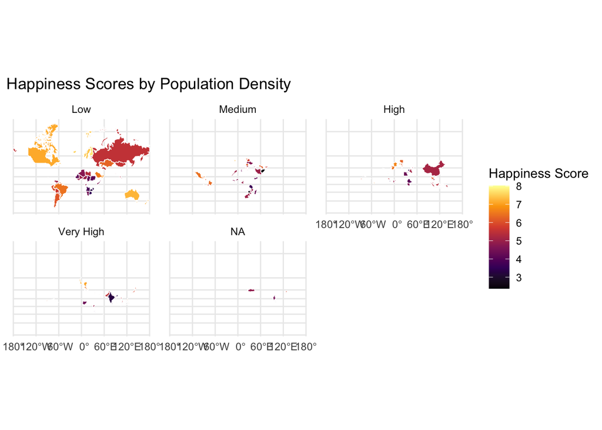

```r
# Visualize happiness by population density
ggplot(merged_sf) +
  geom_sf(aes(fill = `Life Ladder`), color = "white") +
  facet_wrap(~pop_density_category) +
  scale_fill_viridis_c(option = "B") +
  theme_minimal() +
  labs(title = "Happiness Scores by Population Density", fill = "Happiness Score")
```

Average happiness scores varied across these categories, with low-density countries having the highest average happiness (5.76), followed by very high-density countries (5.64), and medium-density countries showing the lowest average happiness (5.08). This suggests a complex relationship between population density and well-being, potentially influenced by governance, resource allocation, or cultural factors.

### Spatial Autocorrelation Analysis

```r
merged_sf <- merged_sf[!is.na(merged_sf$`pop_density_category`), ] # Remove rows with missing happiness scores
```

```r
# Subset coastal and landlocked countries
low_den_countries <- merged_sf[merged_sf$pop_density_category == "Low", ]
mod_den_countries <- merged_sf[merged_sf$pop_density_category == "Medium", ]
high_den_countries <- merged_sf[merged_sf$pop_density_category == "High", ]
very_high_den_countries <- merged_sf[merged_sf$pop_density_category == "Very High", ]

# Create spatial weights for Low Freedom countries
low_den_coords <- st_coordinates(st_centroid(low_den_countries))
low_den_knn <- spdep::knearneigh(low_den_coords, k = 5)
low_den_listw <- spdep::nb2listw(spdep::knn2nb(low_den_knn), style = "W")

# Moran's I for Low Freedom countries
low_den_moran <- spdep::moran.test(low_den_countries$`Life Ladder`, low_den_listw)
print(low_den_moran)
```

```
    Moran I test under randomisation

data:  low_den_countries$`Life Ladder`
weights: low_den_listw

Moran I statistic standard deviate = 34.123, p-value < 2.2e-16
alternative hypothesis: greater
sample estimates:
Moran I statistic       Expectation          Variance
      0.899723894      -0.002403846       0.000698963
```

```r
# Create spatial weights for Moderate Freedom countries
mod_den_coords <- st_coordinates(st_centroid(mod_den_countries))
mod_den_knn <- spdep::knearneigh(mod_den_coords, k = 5)
mod_den_listw <- spdep::nb2listw(spdep::knn2nb(mod_den_knn), style = "W")

# Moran's I for Moderate Freedom countries
mod_den_moran <- spdep::moran.test(mod_den_countries$`Life Ladder`, mod_den_listw)
print(mod_den_moran)
```

```
    Moran I test under randomisation

data:  mod_den_countries$`Life Ladder`
weights: mod_den_listw

Moran I statistic standard deviate = 29.931, p-value < 2.2e-16
alternative hypothesis: greater
sample estimates:
Moran I statistic       Expectation          Variance
     0.7767110780     -0.0023584906      0.0006774891
```

```r
# Create spatial weights for High Freedom countries
high_den_coords <- st_coordinates(st_centroid(high_den_countries))
high_den_knn <- spdep::knearneigh(high_den_coords, k = 5)
high_den_listw <- spdep::nb2listw(spdep::knn2nb(high_den_knn), style = "W")

# Moran's I for High Freedom countries
high_den_moran <- spdep::moran.test(high_den_countries$`Life Ladder`, high_den_listw)
print(high_den_moran)
```

```
    Moran I test under randomisation

data:  high_den_countries$`Life Ladder`
weights: high_den_listw

Moran I statistic standard deviate = 34.934, p-value < 2.2e-16
alternative hypothesis: greater
sample estimates:
Moran I statistic       Expectation          Variance
     0.9176698391     -0.0024154589      0.0006936928
```

```r
# Create spatial weights for High Freedom countries
very_high_den_coords <- st_coordinates(st_centroid(very_high_den_countries))
very_high_den_knn <- spdep::knearneigh(very_high_den_coords, k = 5)
very_high_den_listw <- spdep::nb2listw(spdep::knn2nb(very_high_den_knn), style = "W")

# Moran's I for High Freedom countries
very_high_den_moran <- spdep::moran.test(very_high_den_countries$`Life Ladder`, very_high_den_listw)
print(very_high_den_moran)
```

```
    Moran I test under randomisation

data:  very_high_den_countries$`Life Ladder`
weights: very_high_den_listw

Moran I statistic standard deviate = 31.941, p-value < 2.2e-16
alternative hypothesis: greater
sample estimates:
Moran I statistic       Expectation          Variance
     0.8572851007     -0.0024813896      0.0007245273
```

Moran’s I tests revealed significant spatial clustering of happiness scores within each population density category:

Low Density: Moran’s I = 0.899, indicating strong clustering of happiness scores. Medium Density: Moran’s I = 0.777, showing moderate clustering. High Density: Moran’s I = 0.918, highlighting strong spatial autocorrelation. Very High Density: Moran’s I = 0.857, suggesting robust clustering.

These results showed that happiness scores are not randomly distributed but influenced by geographic proximity and shared regional characteristics.

### Exploratory Visualizations

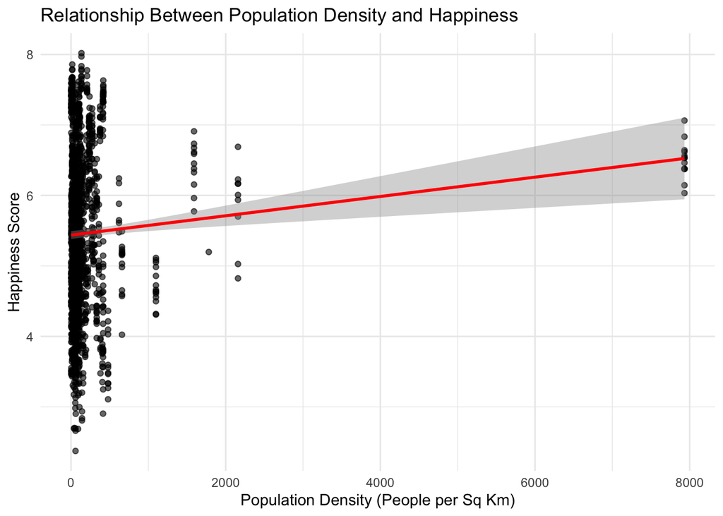

```r
# Scatterplot of Population Density vs. Happiness Score
ggplot(merged_sf, aes(x = pop_density, y = `Life Ladder`)) +
  geom_point(alpha = 0.6) +
  geom_smooth(method = "lm", color = "red", se = TRUE) +
  theme_minimal() +
  labs(
    title = "Relationship Between Population Density and Happiness",
    x = "Population Density (People per Sq Km)",
    y = "Happiness Score"
  )
```

```r
# Compute Moran's I for Population Density
pop_density_nb <- spdep::poly2nb(merged_sf, queen = TRUE)

# Allow empty neighbor sets
pop_density_listw <- spdep::nb2listw(pop_density_nb, style = "W", zero.policy = TRUE)

# Compute Moran's I for Population Density
pop_density_moran <- spdep::moran.test(merged_sf$pop_density, pop_density_listw, zero.policy = TRUE)

# Print the Moran's I result
print(pop_density_moran)
```

```
    Moran I test under randomisation

data:  merged_sf$pop_density
weights: pop_density_listw
n reduced by no-neighbour observations

Moran I statistic standard deviate = 172.83, p-value < 2.2e-16
alternative hypothesis: greater
sample estimates:
Moran I statistic       Expectation          Variance
     9.846116e-01     -6.031363e-04      3.249597e-05
```

### Clustering Analysis

K-Means clustering grouped countries based on happiness scores and population density into three clusters:

```r
merged_sf <- merged_sf %>%
  mutate(`Life Ladder` = as.numeric(`Life Ladder`))
```

```r
library(dplyr)
library(tidyr)
library(cluster)
library(ggplot2)

# Select numeric columns only, excluding geometry
cluster_data <- merged_sf %>%
  st_drop_geometry() %>%  # Drop the geometry column
  select(pop_density, `Life Ladder`) %>%
  drop_na()  # Remove rows with missing values

# Scale the numeric data
cluster_data_scaled <- scale(cluster_data)
```

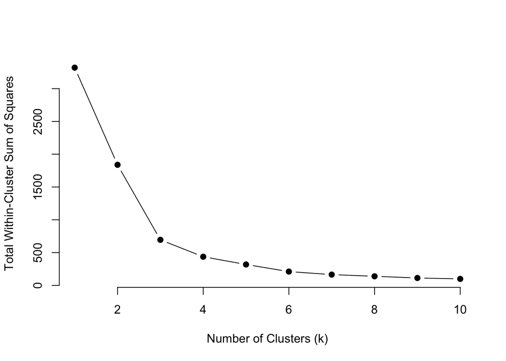

```r
# Determine the optimal number of clusters using the Elbow method
set.seed(123)  # For reproducibility
wss <- map_dbl(1:10, function(k) {
  kmeans(cluster_data_scaled, centers = k, nstart = 25)$tot.withinss
})

# Plot the Elbow method
plot(1:10, wss, type = "b", pch = 19, frame = FALSE,
     xlab = "Number of Clusters (k)",
     ylab = "Total Within-Cluster Sum of Squares")
```

```r
# Perform k-means clustering with the optimal number of clusters
optimal_k <- 3  # Replace with the optimal number from the Elbow plot
kmeans_result <- kmeans(cluster_data_scaled, centers = optimal_k, nstart = 25)

# Add cluster assignments to the original dataset
merged_sf$cluster <- as.factor(kmeans_result$cluster)
```

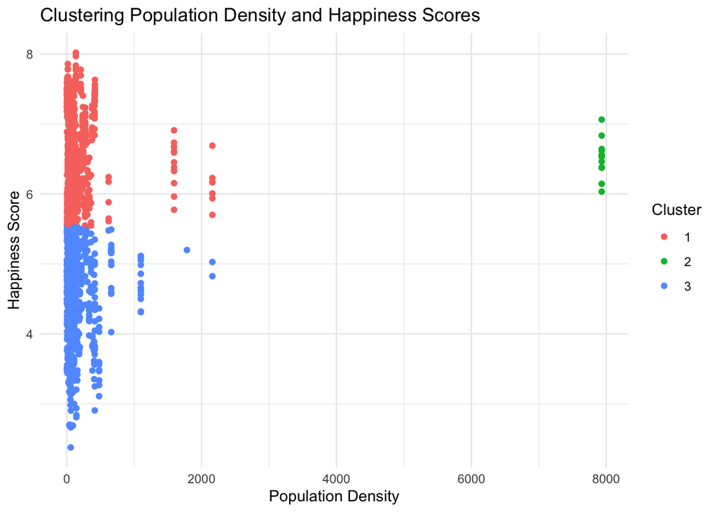

```r
# Scatterplot
ggplot(merged_sf, aes(x = pop_density, y = `Life Ladder`, color = cluster)) +
  geom_point() +
  theme_minimal() +
  labs(title = "Clustering Population Density and Happiness Scores",
       x = "Population Density",
       y = "Happiness Score",
       color = "Cluster")
```

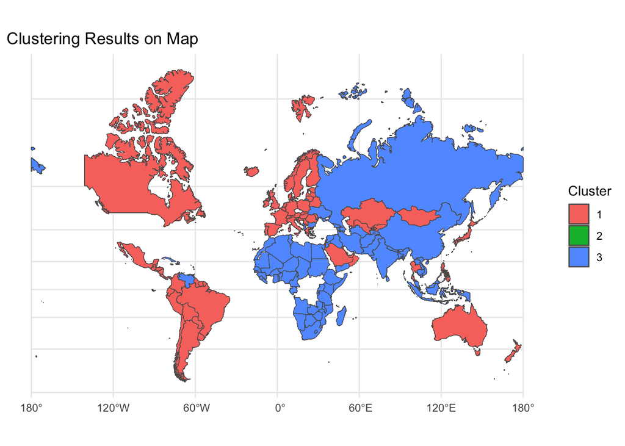

```r
library(sf)

# Spatial Map
ggplot(merged_sf) +
  geom_sf(aes(fill = cluster)) +
  theme_minimal() +
  labs(title = "Clustering Results on Map",
       fill = "Cluster")
```

While low-density countries had the highest average happiness, very high-density regions also exhibited high scores, challenging the assumption that density negatively impacts well-being. Medium-density regions had the lowest happiness, possibly reflecting economic or governance challenges in countries transitioning between rural and urban characteristics.v